# NWIS data

Sandy Sum

8/10/2021

# Contaminants

## Arsenic

[figure not shown]

Sinister uses of Arsenic

> Arsenic is one of the inorganic contaminants regulated under the Phase II/V Rules. In 2001, under the Arsenic Rule, EPA adopted a lower standard for arsenic in drinking water: from 50 ppb to 10 ppb. The lower standard of 10 parts per billion (ppb) replaced the prior standard of 50 ppb (set in 1975 based on a [Public Health Service standard](https://www.epa.gov/dwreginfo/drinking-water-arsenic-rule-history) established in 1942). **PWSs had to comply with the lower standard by January 23, 2006**.

### Arsenic Occurrence and Health Effects

Arsenic occurs naturally in rocks and soil, water, air, and plants and animals. It can be further released into the environment through natural activities such as volcanic action, erosion of rocks, and forest fires, or through human actions. Approximately 90% of industrial arsenic in the U.S. is currently used as a wood preservative, but arsenic is also used in paints, dyes, metals, drugs, soaps, and semi-conductors. Agricultural applications, mining, and smelting also contribute to arsenic releases in the environment.

Higher levels of arsenic tend to be found more in ground water sources than in surface water sources (i.e., lakes and rivers) of drinking water. Compared to the rest of the United States, western states have more systems with arsenic levels greater than 10 ppb. Parts of the Midwest and New England have some systems whose current arsenic levels are greater than 10 ppb, but more systems with arsenic levels that range from 2-10 ppb. While many systems may not have detected arsenic in their drinking water above 10 ppb, there may be geographic “hot spots” with systems that may have higher levels of arsenic than the predicted occurrence for that area.

So the Arsenic rule would only apply (in the sense that they would be monitored and enforced) to communities served by PWSs and not communities served by private wells.

The Arsenic rule would also only **catch** for the CWSs that were already at the margin. I.e. the CWSs that exceeded 10 ppb in 2001.

Arsenic is a semi-metal element in the periodic table. It is odorless and tasteless. It can enter drinking water supplies from natural deposits in the earth or from agricultural and industrial practices.

Non-cancer effects of arsenic can include:

- Thickening and discoloration of the skin,
- Stomach pain,
- Nausea,
- Vomiting,
- Diarrhea,
- Numbness in hands and feet,
- Partial paralysis, and
- Blindness.

Arsenic has been linked to a number of cancers. These include cancer of the bladder, lungs, skin, kidney, nasal passages, liver, and prostate.

### Exploring the Data

ar %>% select(locationId, date, value_ugL, AquiferName, wellDepth_m, constructionDateYr)  
6 Variables 9277 Observations

locationId

| n | missing | distinct |
| --- | --- | --- |
| 9277 | 0 | 3943 |

| lowest : | USGS-323242117062102 | USGS-323242117062103 | USGS-323242117062104 | USGS-323242117062105 | USGS-323313117033901 |
| --- | --- | --- | --- | --- | --- |
| highest: | USGS-415500122270001 | USGS-415522124084301 | USGS-415700121280001 | USGS-415700121550001 | USGS-415800123440001 |

date

```
          n    missing   distinct       Info       Mean        Gmd        .05
       9277          0       3130          1 2010-09-28       2475 1999-04-08
        .10        .25        .50        .75        .90        .95
 2002-04-18 2006-10-18 2011-03-15 2015-08-13 2018-02-14 2019-06-26
```

| lowest : | 1995-01-11 | 1995-01-12 | 1995-01-13 | 1995-01-19 | 1995-01-20 |
| --- | --- | --- | --- | --- | --- |
| highest: | 2020-11-03 | 2020-11-04 | 2020-12-01 | 2020-12-02 | 2020-12-03 |

value_ugL

| n | missing | distinct | Info | Mean | Gmd | .05 | .10 | .25 | .50 | .75 | .90 | .95 |
| --- | --- | --- | --- | --- | --- | --- | --- | --- | --- | --- | --- | --- |
| 9271 | 6 | 843 | 1 | 12.89 | 21.76 | 0.00 | 0.12 | 0.58 | 1.90 | 5.70 | 22.00 | 50.90 |

lowest : 0.00 0.03 0.04 0.05 0.06 , highest: 1030.00 1070.00 1230.00 2750.00 3560.00

AquiferName

| n | missing | distinct |
| --- | --- | --- |
| 7813 | 1464 | 6 |

| lowest : | Basin and Range basin-fill aquifers | California Coastal Basin aquifers | Central Valley aquifer system | Other aquifers | Pacific Northwest basin-fill aquifers |
| --- | --- | --- | --- | --- | --- |
| highest: | California Coastal Basin aquifers | Central Valley aquifer system | Other aquifers | Pacific Northwest basin-fill aquifers | Pacific Northwest volcanic-rock aquifers |

Basin and Range basin-fill aquifers (3532, 0.452), California Coastal Basin aquifers (2062, 0.264), Central Valley aquifer system (1489, 0.191), Other aquifers (547, 0.070), Pacific Northwest basin-fill aquifers (126, 0.016), Pacific Northwest volcanic-rock aquifers (57, 0.007)

wellDepth_m

| n | missing | distinct | Info | Mean | Gmd | .05 | .10 | .25 | .50 | .75 | .90 | .95 |
| --- | --- | --- | --- | --- | --- | --- | --- | --- | --- | --- | --- | --- |
| 8661 | 616 | 966 | 1 | 138.7 | 113.7 | 18.29 | 30.48 | 58.70 | 111.56 | 195.07 | 280.42 | 344.12 |

| lowest : | 0.97536 | 4.23672 | 4.35864 | 4.48056 | 4.57200 |
| --- | --- | --- | --- | --- | --- |
| highest: | 746.76000 | 762.00000 | 798.57600 | 811.98720 | 883.92000 |

constructionDateYr

| n | missing | distinct | Info | Mean | Gmd | .05 | .10 | .25 | .50 | .75 | .90 | .95 |
| --- | --- | --- | --- | --- | --- | --- | --- | --- | --- | --- | --- | --- |
| 7776 | 1501 | 96 | 0.999 | 1991 | 18.4 | 1958 | 1967 | 1980 | 1993 | 2004 | 2010 | 2012 |

lowest : 1909 1920 1921 1922 1923 , highest: 2015 2016 2017 2018 2019

## Monitoring stations

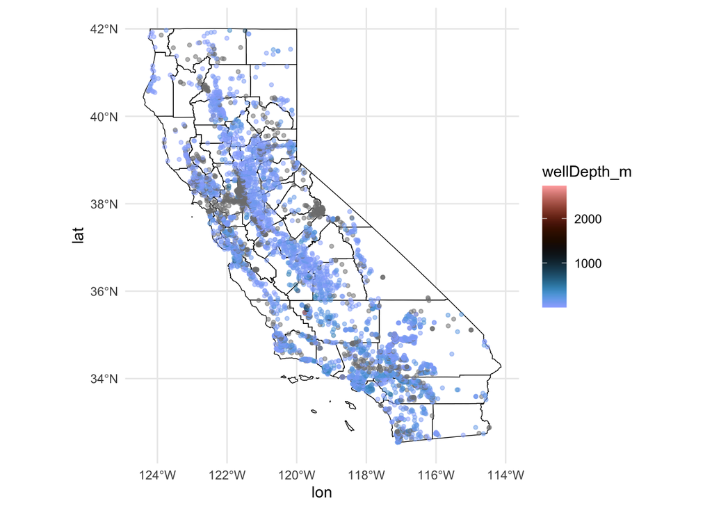

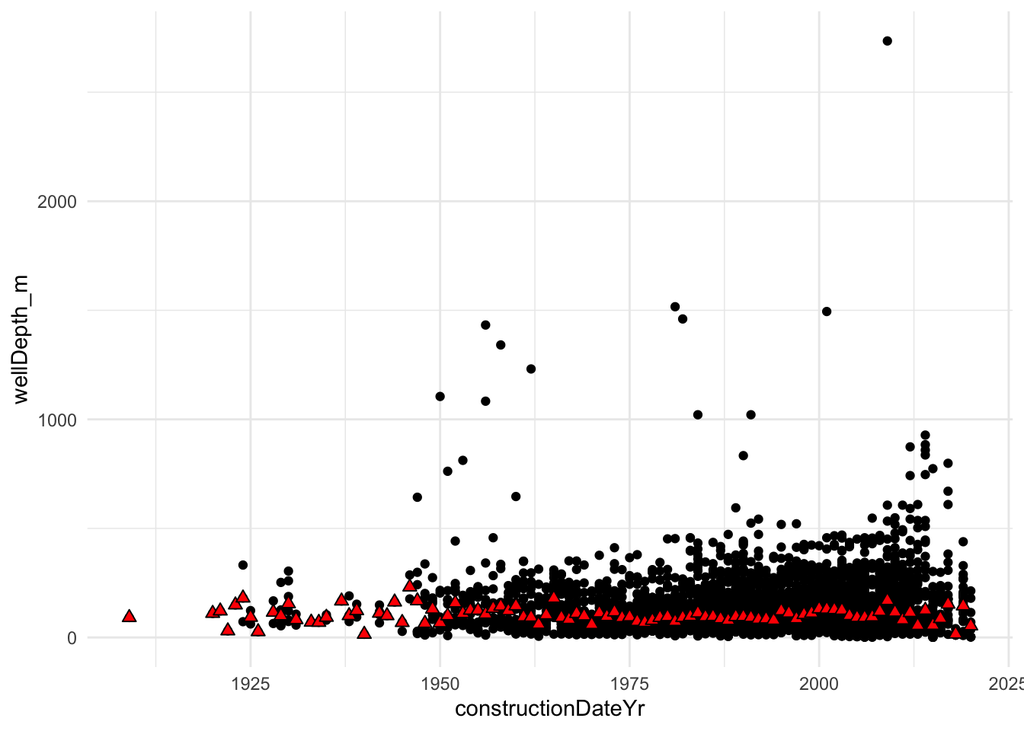